# RNA-seq analysis in R

Gene Set Testing for RNA-seq

Stephane Ballereau, Mark Dunning, Oscar Rueda, Ashley Sawle

Last modified: 19 Jun 2018

**Original Authors: Belinda Phipson, Anna Trigos, Matt Ritchie, Maria Doyle, Harriet Dashnow, Charity Law** Based on the course [RNAseq analysis in R](http://combine-australia.github.io/2016-05-11-RNAseq/) delivered on May 11/12th 2016

# Data set

- Organism: mouse
- Tissue: mammary gland
- Three conditions:
  - virgin
  - pregnant
  - lactating
- Two cell types:
  - basal stem-cell enriched cells (B)
  - committed luminal cells (L)
- Six groups (3 conditions x 2 cell types) with 2 biological replicates per group
- As described in:
  - [‘EGF-mediated induction of Mcl-1 at the switch to lactation is essential for alveolar cell survival’ (Fu et al. 2015)](https://www.ncbi.nlm.nih.gov/pubmed/25730472) published in Nature Cell Biology, with both sequence and counts available from Gene Expression Omnibus database (GEO) under accession number GSE60450
  - [A DE-licious recipe for differential expression analyses of RNA-seq](http://www.statsci.org/smyth/pubs/QLedgeRPreprint.pdf)

# Gene Set Testing

In the early days of microarray analysis, people were happy if they got a handful of differentially-expressed genes that they could validate or follow-up. However, with later technologies (and depending on the experimental setup) we might have thousands of statistically-significant results, which no-one has the time to follow-up. Also, we might be interested in pathways / mechanisms that are altered and not just individual genes.

In this section we move towards discovering if our results are *biologically significant*. Are the genes that we have picked statistical flukes, or are there some commonalities.

There are two different approaches one might use, and we will cover the theory behind both

- There is also a bunch of websites for doing the tests
  - we will show how they are done in Bioconductor so the theory is clear
- We will assume we have done a differential-expression analysis, but the same techniques can be used for other situations when we have a gene list
  - ChIP-seq
  - RNA-seq

## Theory Part I: Over-representation analysis

- “Threshold-based”: require defintion of a statistical threshold to define list of genes to test (e.g. FDR < 0.01)
- Hypergeometric test or Fisher’s Exact test generally used.

The question we are asking here is;

> *“Are the number of DE genes associated with Theme X significantly greater than what we might expect by chance alone?”*

Where Theme X could be genes belonging to a particular GO (Gene Onotology) term.

Let’s imagine that we have a bag full of balls. Each balls represents a gene in the *gene universe*. - Paint the balls representing our selected list grey, and paint the rest red.

Now, lets select a number (say, 12) of the balls at random without seeing into the bag and look at what we get

We have picked, at random, 8 grey balls. Using simulations, we can repeat the process and look at how many grey we get. We can (of course!) do this in R. In base R there is a family of functions that can generate random draws from various distributions; `rnorm`, `rbinom`, `rhyper` etc….

The distribution of the data shows what the most-likely values are

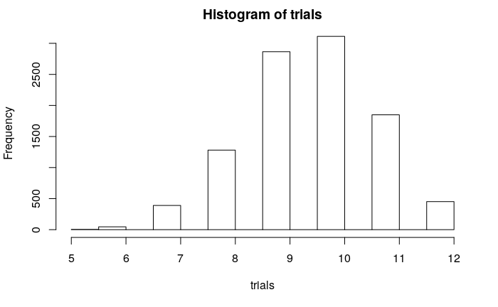

```r
#see ?rhyper for argument definition
trials <- rhyper(10000,40,10,12)
hist(trials)
```

We can count how many times each value is observed

```r
table(trials)
```

```
trials
   5    6    7    8    9   10   11   12
   5   46  390 1281 2865 3112 1849  452
```

Dividing by the number of trials gives a probability of sorts

```r
table(trials)/10000
```

```
trials
     5      6      7      8      9     10     11     12
0.0005 0.0046 0.0390 0.1281 0.2865 0.3112 0.1849 0.0452
```

```r
cumsum(table(trials)/10000)
```

```
     5      6      7      8      9     10     11     12
0.0005 0.0051 0.0441 0.1722 0.4587 0.7699 0.9548 1.0000
```

```r
1-cumsum(table(trials)/10000)
```

```
     5      6      7      8      9     10     11     12
0.9995 0.9949 0.9559 0.8278 0.5413 0.2301 0.0452 0.0000
```

Back to our example, the distribution of balls can be expressed as a contingency table, on which we can use a Fisher’s exact test

|  | In Selection |
| --- | --- |
| Grey | 8 |
| Not Grey | 4 |
| Total | 12 |

The formula for Fisher’s exact test is defined with reference to the cells of the 2 x 2 table

[output not shown]

The formula for Fishers exact test is;

$$p = \frac{\binom{a + b}{a}\binom{c +d}{c}}{\binom{n}{a +c}} = \frac{(a+b)!(c+d)!(a+c)!(b+d)!}{a!b!c!d!n!}$$

or less formally;

*P = (ways of choosing grey balls) X (ways of non-grey balls amongst subset) / ways of choosing subset*

Fortunately, we do not need to plug the numbers into these formulas manually and several packages for performing gene set testing exist which also account for the complexity of RNA-seq data.

## Gene Set Testing - competitive gene set tests

### GOseq analysis

GOseq is a method to conduct Gene Ontology (GO) analysis suitable for RNA-seq data as it accounts for the gene length bias in detection of over-representation ([GOseq article](https://genomebiology.biomedcentral.com/articles/10.1186/gb-2010-11-2-r14))

From the [GOseq vignette](https://www.bioconductor.org/packages/release/bioc/vignettes/goseq/inst/doc/goseq.pdf):

- GOseq first needs to quantify the length bias present in the dataset under consideration.
- This is done by calculating a Probability Weighting Function or PWF which can be thought of as a function which gives the probability that a gene will be differentially expressed (DE), based on its length alone.
- The PWF is calculated by fitting a monotonic spline to the binary data series of differential expression (1=DE, 0=Not DE) as a function of gene length.
- The PWF is used to weight the chance of selecting each gene when forming a null distribution for GO category membership.
- The fact that the PWF is calculated directly from the dataset under consideration makes this approach robust, only correcting for the length bias present in the data.

“GO analysis of RNA-seq data requires the use of random sampling in order to generate a suitable null distribution for GO category membership and calculate each category’s significance for over representation amongst DE genes. … In most cases, the Wallenius distribution can be used to approximate the true null distribution, without any significant loss in accuracy. The goseq package implements this approximation as its default option.”

Create list of DEGs:

```r
library(DESeq2)
load("Robjects/DE.Rdata")
## Make sure NA values are removed before continuing
results.noNA <- results[!is.na(results$padj),]
# Derive list of DEGs by filtering on adjusted p-value
genes <- results.noNA$padj < 0.05
# Add gene names to that list:
names(genes) <- rownames(results.noNA)
print(head(genes))
```

```
497097  20671  27395  18777  21399  58175
 FALSE  FALSE  FALSE  FALSE  FALSE  FALSE
```

Fit the Probability Weighting Function (PWF):

```
Can't find mm10/knownGene length data in genLenDataBase...
Found the annotaion package, TxDb.Mmusculus.UCSC.mm10.knownGene
Trying to get the gene lengths from it.
initial point very close to some inequality constraints
```

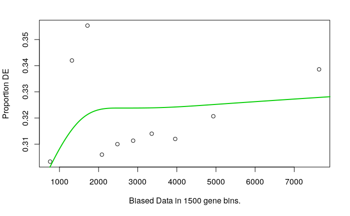

```r
library(goseq)
#print(supportedGeneIDs())
#print(supportedGenomes())
pwf <- nullp(genes, "mm10","knownGene")
```

Conduct gene set enrichment analysis:

```r
#?goseq
go.results <- goseq(pwf, "mm10","knownGene")
```

```r
go.results
```

[output not shown]

### fgsea analysis

From the fgsea [vignette](http://www.bioconductor.org/packages/release/bioc/vignettes/fgsea/inst/doc/fgsea-tutorial.html) “fast preranked gene set enrichment analysis (GSEA)”:

This analysis is performed by:

- 1. ranking all genes in the data set based on their correlation to the chosen phenotype,
- 2. identifying the rank positions of all members of the gene set, and
- 3. calculating an enrichment score (ES) that represents the difference between the observed rankings and that which would be expected assuming a random rank distribution.

“After establishing the ES for each gene set across the phenotype, GSEA reiteratively randomizes the sample labels and retests for enrichment across the random classes. By performing repeated class label randomizations, the ES for each gene set across the true classes can be compared to the ES distribution from the random classes. Those gene sets that significantly outperform iterative random class permutations are considered significant.” [commentary on GSEA](https://www.ncbi.nlm.nih.gov/pmc/articles/PMC1266131/). The article describing the original software is available [here](http://www.pnas.org/content/102/43/15545.long).

```r
library(fgsea)
```

Create ranks:

```r
results.ord <- results[ order(-results[,"log2FoldChange"]), ]
head(results.ord)
```

```
log2 fold change (MLE): CellType luminal vs basal
Wald test p-value: CellType luminal vs basal
DataFrame with 6 rows and 6 columns
                  baseMean   log2FoldChange            lfcSE             stat               pvalue                 padj
                 <numeric>        <numeric>        <numeric>        <numeric>            <numeric>            <numeric>
73349     39.2780035601196 7.92367716772925 1.71105710453522 4.63086658342801 3.64138463015372e-06 0.000257268835200127
55961     24.3662590040623 7.71571538787165 1.76700035907949 4.36656130160105 1.26217875589577e-05 0.000625082868112754
100034251 480.428476572601 7.71466202472615 1.37950930587762  5.5923232934034 2.24051134854562e-08 1.11317276742902e-05
67280     31.0492163398872 7.58188004639279 1.76707697102969 4.29063372489925  1.7816396204523e-05 0.000786349048091212
16591     67.1741074541126 7.53122431495289 1.25584524466028 5.99693660263862 2.01074513494989e-09 5.09882450754772e-06
11941     2273.58037672806 7.46165442637302 1.38476514351554 5.38838983730475 7.10917172277925e-08 2.12660165264524e-05
```

```r
ranks <- results.ord$log2FoldChange
names(ranks) <- rownames(results.ord)
head(ranks)
```

```
    73349     55961 100034251     67280     16591     11941
 7.923677  7.715715  7.714662  7.581880  7.531224  7.461654
```

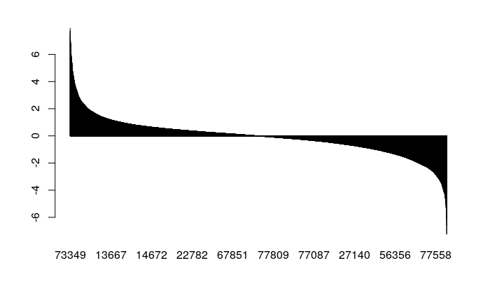

```r
#plot(ranks)
barplot(ranks)
```

Load pathways:

```r
load("data/mouse_H_v5.rdata")
pathways <- Mm.H
```

Conduct analysis:

```r
library(fgsea)
?fgsea
fgseaRes <- fgsea(pathways, ranks, minSize=15, maxSize = 500, nperm=1000)
class(fgseaRes)
```

```
[1] "data.table" "data.frame"
```

```r
dim(fgseaRes)
```

```
[1] 50  8
```

```r
#head(fgseaRes)
```

Glance at results:

```r
head(fgseaRes[order(padj), ])
```

```
                       pathway        pval       padj         ES       NES nMoreExtreme size                               leadingEdge
1:     HALLMARK_G2M_CHECKPOINT 0.003460208 0.01349528  0.4245462  1.812483            0  199   13645,18005,17345,15366,26909,11799,...
2:       HALLMARK_ADIPOGENESIS 0.003508772 0.01349528  0.4252592  1.811832            0  194  12683,16956,246747,18405,11520,13358,...
3:         HALLMARK_MYOGENESIS 0.001416431 0.01349528 -0.5046299 -1.947157            0  174   11464,21953,12373,17967,12709,13527,...
4:    HALLMARK_APICAL_JUNCTION 0.001428571 0.01349528 -0.4701791 -1.823627            0  185  11464,11468,12563,98932,11459,244864,...
5: HALLMARK_HEDGEHOG_SIGNALING 0.003367003 0.01349528 -0.5757347 -1.669640            1   30 104001,319504,21838,14766,22359,12804,...
6:   HALLMARK_MTORC1_SIGNALING 0.003460208 0.01349528  0.3978742  1.698090            0  201 20249,14718,107476,104112,17436,22433,...
```

Plot outcome for the ‘HALLMARK_MYOGENESIS’ pathway:

First find rank of the ‘HALLMARK_MYOGENESIS’ pathway genes in the sorted genes:

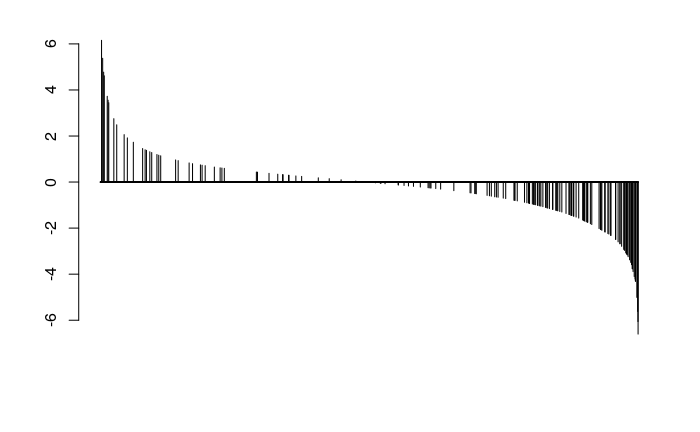

```r
# We will create a barplot of logFC for the sorted genes and add one vertical red bar for each gene in the 'HALLMARK_MYOGENESIS' pathway
#pathways[["HALLMARK_MYOGENESIS"]]
tmpInd <- match(pathways[["HALLMARK_MYOGENESIS"]],names(ranks))
tmpInd <- tmpInd[!is.na(tmpInd)]
#tmpInd
ranks2 <- rep(0,length(ranks))
ranks2[tmpInd] <- ranks[tmpInd]
barplot(ranks2)
```

Create enrichment score plot:

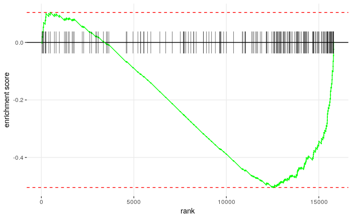

```r
plotEnrichment(pathways[["HALLMARK_MYOGENESIS"]],
               ranks)
```

Remember to check the [GSEA article](http://www.pnas.org/content/102/43/15545.full) for the complete explanation.

Select top pathways and plot outcome for all these:

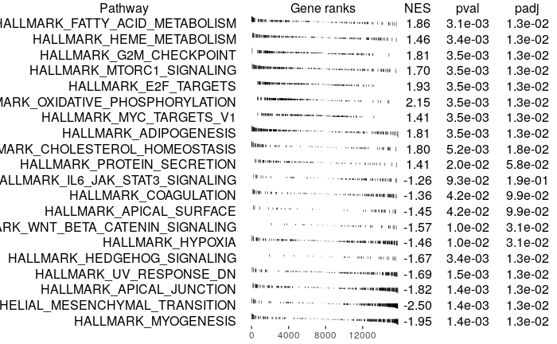

```r
topPathwaysUp <- fgseaRes[ES > 0][head(order(pval), n=10), pathway]
topPathwaysDown <- fgseaRes[ES < 0][head(order(pval), n=10), pathway]
topPathways <- c(topPathwaysUp, rev(topPathwaysDown))
plotGseaTable(pathways[topPathways], ranks, fgseaRes,
              gseaParam = 0.5)
```

```r
?plotGseaTable
```

## Creating Gene lists to use with an online tool

There are also many online tools that one could use to perform a gene set or ontology analysis.

- [DAVID](https://david.ncifcrf.gov/)
- [GeneTrail](https://genetrail2.bioinf.uni-sb.de/)
- [GORilla](http://cbl-gorilla.cs.technion.ac.il/)

The tools generally require your input genes lists to be uploaded as a simple text file. In this final challenge, we will create some files that you might use in one of these tools.

### A file containing names of background genes

This file has one column which lists **all the gene names** present in the analysis. Gene Symbols are commonly used, although a tool may accept Ensembl or Refseq names

### A file containing names of significant genes

This file has one column which lists the genes that passed the threshold for statistical significance (e.g. p-value less than 0.05) in your analysis. Gene Symbols are commonly used, although a tool may accept Ensembl or Refseq names

## Challenge

> Create two text files that can be imported into online tools for further analysis 1. A list of background genes 2. A list of differentially expressed genes 3. Load these files into GOrilla for analysis HINT: the `write.table` function is able to write a data frame to a txt file in R. You will need to set the appropriate arguments to make sure that a text file with only one column is created.